# perfectPGT

```python
from IPython.display import Image
import numpy as np
from matplotlib import pyplot as plt
%matplotlib inline
from adsy.display import extended_styles
from collections import defaultdict
```

```python
extended_styles()
```

Toggle Input

### A Game of perfect information

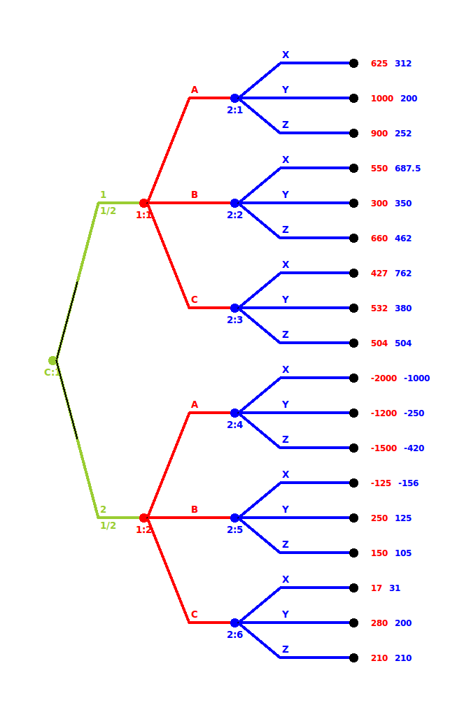

```python
Image('perfectinfo.png')
```

- This game has 72 Nash equilibria
- Only 1 of the equilibria is "subgame perfect"
- However, we know the MCTS and CRM for multiplayers have no theoretical guarantees to converge to the subgame perfect equilibrium.
- For reference, the subgame perfect strategy for player 1 is (A if 1, B if 2) and for player 2 is (X if (1,A), X if (1, B), X if (1, C), Y if (2,A), Y if (2,B), Z if (2,C))

### PGT Intelligence

- The intelligence of a strategy profile of both players $(s_1, s_2)$ is the intelligence of $s_1$ against $s_2$ times the intelligence of $s_2$ against $s_1$.
- The intelligence of $s_1$ against $s_2$ is the fraction of player 1's strategies that do worse (lower expected utility) against $s_2$ than $s_1$.
- All Nash equilibrium strategy profiles have an intelligence of 1

### Trembling

- Instead of computing the intelligence of $s_1$ against $s_2$ as the proportion of profiles that do worse than $s_1$ against $s_2$, we assume the player 2 plays $s_2$ with probability $p$ and trembles uniformly over all other strategies with probability $(1-p)$. Then we compute player 1's expected utility by averaging over player 2's trambles. The intellgience is then the proportion of player 1's stratgies that do worse than $s_1$ against the "trembling" $s_2$
- We can show (analytically) that under any tremble probability, a strategy profile has an intelligence of 1 iff it is subgame perfect.
- However, since intelligence ultimately determine the probability distribution voer outcomes (profiles with higher intelligence have higher probability of being played) we are interested to see the trembling intelligences of the non-subgame perfect equilibria.

### Some code

```python
extended_styles()
```

Toggle Input

```python
import itertools
perfect_strat_1 = list(itertools.product(["A", "B", "C"], ["A", "B", "C"]))
perfect_strat_2 = list(itertools.product(["X", "Y", "Z"], ["X", "Y", "Z"], ["X", "Y", "Z"],
                                         ["X", "Y", "Z"], ["X", "Y", "Z"], ["X", "Y", "Z"]))
perfect_stratprofiles = list(itertools.product(perfect_strat_1, perfect_strat_2))
mapdict = {"A": 0, "B":1, "C":2}
utils = {"HAX": (625, 312),
         "HAY": (1000, 200),
         "HAZ": (900, 252),
         "HBX": (550, 687.5),
         "HBY": (300, 350),
         "HBZ": (660, 462),
         "HCX": (427, 762),
         "HCY": (532, 380),
         "HCZ": (504, 504),
         "LAX": (-2000, -1000),
         "LAY": (-1200, -250),
         "LAZ": (-1500, -420),
         "LBX": (-125, -156),
         "LBY": (250, 125),
         "LBZ": (150, 105),
         "LCX": (17, 31),
         "LCY": (280, 200),
         "LCZ": (210, 210)
}
```

```python
def EU_with_trembles_perfect_info(p1strat, p2strat, utils=utils, p1top2map=mapdict, p1trembleprob=.2,
                     p2trembleprob=.2, p1tremblestrats=perfect_strat_1, p2tremblestrats=perfect_strat_2):
    """
    Computes the expected utility of player 1 and player 2.

    Nature node is hard coded to p=.5 for both outcomes.

    Setting trembleprobs to 0 gives standard intelligence
    """
    highukey = "H"+p1strat[0]+p2strat[mapdict[p1strat[0]]]
    lowukey =  "L"+p1strat[1]+p2strat[3 + mapdict[p1strat[1]]]
    p1eunotremb = (1-p2trembleprob) * (.5 * utils[highukey][0] + .5 * utils[lowukey][0])
    p2eunotremb = (1-p1trembleprob) * (.5 * utils[highukey][1] + .5 * utils[lowukey][1])
    if p1trembleprob + p2trembleprob ==0:
        return p1eunotremb, p2eunotremb
    ### Get the utility that is associated with p2 trembling
    p1epovern = p1trembleprob/float(len(p1tremblestrats) - 1)
    p2epovern = p2trembleprob/float(len(p2tremblestrats) - 1)
    p1tremblingeu = 0 # Utility of p1 when p2 trembles
    p2tremblingeu = 0 # Utility of p2 when p1 trembles
    for s in p2tremblestrats:
        if s != p2strat:
            highukey = "H"+p1strat[0]+s[mapdict[p1strat[0]]]
            lowukey =  "L"+p1strat[1]+s[3 + mapdict[p1strat[1]]]
            p1tremblingeu += p2epovern * (.5 * utils[highukey][0] + .5 * utils[lowukey][0])
    for s in p1tremblestrats:
        if s != p1strat:
            highukey = "H"+s[0]+p2strat[mapdict[s[0]]]
            lowukey =  "L"+s[1]+p2strat[3 + mapdict[s[1]]]
            p2tremblingeu += p1epovern * (.5 * utils[highukey][1] + .5 * utils[lowukey][1])
    return p1eunotremb + p1tremblingeu, p2eunotremb + p2tremblingeu

def get_trembling_intelligence_perfect_info(profile, p1trembleprob=.2, p2trembleprob=.2):
    """
    Get's the trembling intelligence of a profile under trembling
    """
    p1strat = profile[0]
    p2strat = profile[1]
    util = EU_with_trembles_perfect_info(p1strat, p2strat, p1trembleprob=p1trembleprob, p2trembleprob=p2trembleprob)
    #print util
    p1_numalt = float(len(perfect_strat_1))
    p2_numalt = float(len(perfect_strat_2))
    num_no_betterp1 = 0
    num_no_betterp2 = 0
    for s in perfect_strat_1:
        if EU_with_trembles_perfect_info(s, p2strat, p1trembleprob=p1trembleprob, p2trembleprob=p2trembleprob)[0] <= util[0]:
            num_no_betterp1 +=1
    for s in perfect_strat_2:
        if EU_with_trembles_perfect_info(p1strat, s, p1trembleprob=p1trembleprob, p2trembleprob=p2trembleprob)[1] <= util[1]:
            num_no_betterp2 +=1
    return (num_no_betterp1-1)/(p1_numalt - 1) * (num_no_betterp2 - 1)/(p2_numalt -1)
```

```python
# Get the PGT distribution for various trembling probabilities
#p1tremb=.2
#p2tremb=.2
#trembling_intels_perfect = []
#for p in perfect_stratprofiles:
#    trembling_intels_perfect.append(get_trembling_intelligence_perfect_info(p, p1tremb,p2tremb))

p1tremb=.1
p2tremb=.1
trembling_intels_perfect2 = []
for p in perfect_stratprofiles:
    trembling_intels_perfect2.append(get_trembling_intelligence_perfect_info(p, p1tremb,p2tremb))

#p1tremb=.05
#p2tremb=.05
#trembling_intels_perfect3 = []
#for p in perfect_stratprofiles:
#    trembling_intels_perfect3.append(get_trembling_intelligence_perfect_info(p, p1tremb,p2tremb))

#p1tremb=.01
#p2tremb=.01
#trembling_intels_perfect4 = []
#for p in perfect_stratprofiles:
#    trembling_intels_perfect4.append(get_trembling_intelligence_perfect_info(p, p1tremb,p2tremb))
```

```python
# Results_Class
class TremblingIntelResults(object):
    def __init__(self, res, stratprofiles = perfect_stratprofiles, perfect_strat_1=perfect_strat_1,
                 perfect_strat_2=perfect_strat_2):
        self.res = np.asarray(res)
        self.stratprofiles = stratprofiles
        self.sorted_ix = np.argsort(self.res)[::-1]
        self.perfect_strat_1 = perfect_strat_1
        self.perfect_strat_2 = perfect_strat_2

    def make_hist(self):
        plt.hist(self.res)

    def EU_perfect_info(self, p1strat, p2strat, utils=utils, p1top2map=mapdict):
        """
        No trembling EU.  USed to get Nash-eq
        """
        highukey = "H"+p1strat[0]+p2strat[mapdict[p1strat[0]]]
        lowukey =  "L"+p1strat[1]+p2strat[3 + mapdict[p1strat[1]]]
        p1eu = .5 * utils[highukey][0] + .5 * utils[lowukey][0]
        p2eu = .5 * utils[highukey][1] + .5 * utils[lowukey][1]
        return p1eu, p2eu

    def get_perfect_intelligence(profile):
        """
        Get's the non-trembling intelligences"""
        p1strat = profile[0]
        p2strat = profile[1]
        util = EU_perfect_info(p1strat, p2strat)
        #print util
        p1_numalt = float(len(self.perfect_strat_1))
        p2_numalt = float(len(self.perfect_strat_2))
        num_no_betterp1 = 0
        num_no_betterp2 = 0
        for s in self.perfect_strat_1:
            if EU_perfect_info(s, p2strat)[0] <= util[0]:
                num_no_betterp1 +=1
        for s in self.perfect_strat_2:
            if EU_perfect_info(p1strat, s)[1] <= util[1]:
                num_no_betterp2 +=1
        return (num_no_betterp1-1)/(p1_numalt - 1) * (num_no_betterp2 - 1)/(p2_numalt -1)

    def get_perfect_info_dist():
        intels_perfect = []
        for p in self.stratprofiles:
            intels_perfect.append(self.get_perfect_intelligence(p))
        return intels_perfect

    def eu_dist(self, power = 1, binwidth=10):
        total_prob = np.sum(self.res**power)
        probs = self.res**power/float(total_prob)
        eus = []
        for s in self.stratprofiles:
            eus.append(self.EU_perfect_info(s[0], s[1]))
        p1u = defaultdict(int)
        p2u = defaultdict(int)
        for ix, atom in enumerate(eus):
            p1u[int(atom[0]/binwidth) * binwidth ] += probs[ix]
            p2u[int(atom[1]/binwidth) * binwidth ] += probs[ix]
        return p1u, p2u

    def eu_hist(self, power=1, binwidth=10):
        eu_dicts = self.eu_dist(power=power, binwidth=binwidth)
        eu_subgame_perfect = [(625+250)/2. , (312. + 125.)/2.]
        eu_dicts_exact = self.eu_dist(power=power, binwidth=1)
        p1eeu = 0
        p2eeu = 0
        for k, v in eu_dicts_exact[0].iteritems():
            p1eeu += k * v
        for k, v in eu_dicts_exact[1].iteritems():
            p2eeu += k * v
        fig, [ax1, ax2] = plt.subplots(2)
        ax1.bar(eu_dicts[0].keys(), eu_dicts[0].values(), width=binwidth, color='r', alpha=.35)
        ax1.set_xlabel("Leader\'s expected utility")
        ax1.set_ylabel("Probability")
        ax1.vlines(eu_subgame_perfect[0], 0, .2)
        ax1.vlines(p1eeu, 0, .2, color='green')
        ax2.bar(eu_dicts[1].keys(), eu_dicts[1].values(), width=binwidth, color='r', alpha=.25)
        ax2.set_xlabel("Followers\'s expected utility")
        ax2.set_ylabel("Probability")
        ax2.vlines(eu_subgame_perfect[1], 0, .2)
        ax2.vlines(p2eeu, 0, .2, color='green')
        plt.tight_layout()
        fig.text(1, .5, 'The green vertical line is the expected utility of the intelligence profile. \n' + \
                        'The black line is the SPNE expected utility')
        return fig, ax1, ax2

    def eu_cdf(self, power=1):
        p1_dist, p2_dist = self.eu_dist( power = power)
        p1k = p1_dist.keys()
        p1v = p1_dist.values()
        p1_srtd = np.argsort(p1k)
        cumprob_p1 = np.cumsum(np.asarray(p1v)[p1_srtd])
        p2k = p2_dist.keys()
        p2v = p2_dist.values()
        p2_srtd = np.argsort(p2k)
        cumprob_p2 = np.cumsum(np.asarray(p2v)[p2_srtd])
        fig, [ax1, ax2] = plt.subplots(2)
        ax1.plot(np.asarray(p1k)[p1_srtd], cumprob_p1)
        ax1.set_xlabel("CDF of Leader\'s Utility")
        ax2.plot(np.asarray(p2k)[p2_srtd], cumprob_p2)
        ax2.set_xlabel("CDF of Followers\'s Utility")
        plt.tight_layout()
        return fig, ax1, ax2
```

# Trembling Utilities in games of Perfect Information

### Distribution of utilities

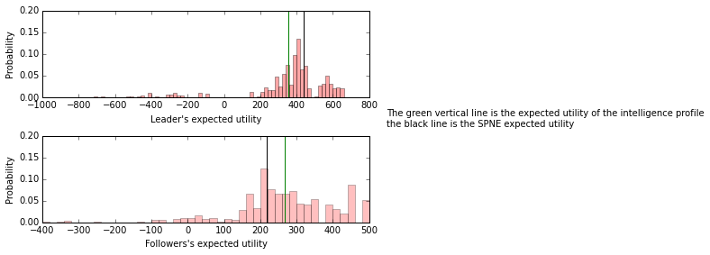

```python
res_tremble10 = TremblingIntelResults(trembling_intels_perfect2)
res_tremble10.eu_hist(binwidth=20, power=1);
```

Remember we have the exponent parameter in the definition of intelligence that puts more weight on high intelligence profiles. Let's see what happens when we raise that

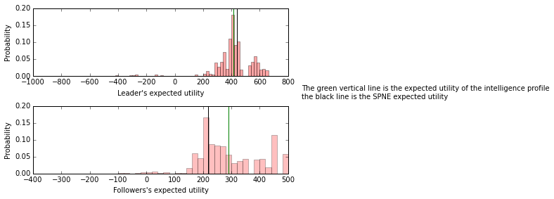

```python
res_tremble10.eu_hist(binwidth=20, power=2);
```

### Vs. Non trembling

One thing we haven't looked at is the difference between the trembling PGT profile and the non-trembling PGT profile. Let's take a look.

```python
p1tremb=0
p2tremb=0
no_trembling_intels = []
for p in perfect_stratprofiles:
    no_trembling_intels.append(get_trembling_intelligence_perfect_info(p, p1tremb, p2tremb))
```

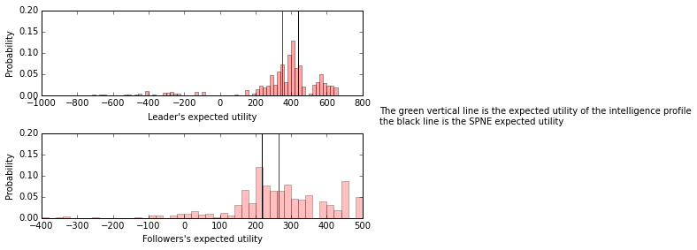

```python
res_notremble = TremblingIntelResults(no_trembling_intels)
res_notremble.eu_hist(binwidth=20, power=1);
```

The distribution of expected utilities look almost exactly the same. Let's see what the difference in strategy profile intelligences.

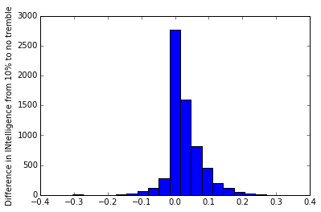

```python
fig, ax = plt.subplots()
ax.hist((np.asarray(no_trembling_intels)/np.sum(no_trembling_intels) -
         np.asarray(trembling_intels_perfect2)/np.sum(no_trembling_intels)) *
            (np.sum(no_trembling_intels) + np.sum(no_trembling_intels))/2. ,
        bins=20);
ax.set_ylabel("Difference in INtelligence from 10% to no tremble");
```

There are only small changes in intelligence for many of the profiles. However, look what happens when we crank the exponent parameter up to infinity.

First with the trembles

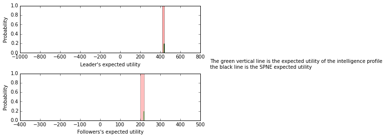

```python
res_tremble10.eu_hist(binwidth=20, power=100000);
```

Then without:

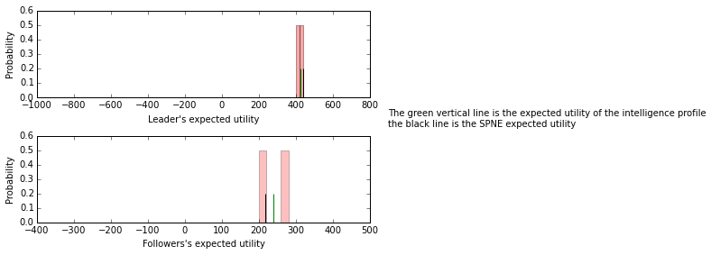

```python
res_notremble = TremblingIntelResults(no_trembling_intels)
res_notremble.eu_hist(binwidth=20, power=1000000000);
```

We see that without trembling, the distribution of strategy profiles will put positive weight on all Nash equilibria. (Note that although there are 72 Nash equilibria in this game, there are only 2 observed outcomes in all of the Nash equilibria, that is why there are only 2 bars, not 72).

# Off path Intelligence in Games of Perfect Information

Here we combine the real intelligence with the full game intelligence described by James as:

1. Calculate the intelligence of $s_L$ and $s_F$ in the usual way, i.e. on-path, and call it $IQ(i,s,on-path)$. While doing that, keep track of all unvisited information sets for each player, i.e. the set of off-path information sets, $H_i$.
2. For each player $i$, for each unvisited information set $h$ in $H_i$, and for each state $n$ in $h$, calculate the intelligence of $s_i$ in information set $h$ given that the state is $n$, call this $IQ(i,s,n)$.
3. For each player $i$, for each unvisited information set $h$, take the average intelligence across nodes $n$ in $h$: $IQ(i,s,h)=1/|h| * \sum_{n\in h} IQ(i,s,n)$
4. Take the average of $IQ(i,s,h)$ across unvisited information sets in $H_i: IQ(i,s,off-path) = 1/|H_i| * sum_{h\in H_i} IQ(i,s,h).$
5. Calculate $IQ(i,s,full-game)$ = $p*IQ(i,s,on-path) + (1-p)*IQ(i,s,off-path)$, where p is a parameter we control based on the importance of off-path play. Let’s start with something like $p=.5$.

### Some more code

```python
on_path_intel = no_trembling_intels # Copied from above just for new varname.
p2_info_sets = ["HA", "HB", "HC", "LA", "LB", "LC"]
def get_off_path_info_sets(profile, p2_info_sets = p2_info_sets):
    unvisited = set(p2_info_sets) - set(["H" + profile[0][0]])
    unvisited = unvisited - set(["L" + profile[0][1]])
    return unvisited
```

```python
def get_off_path_intel_perfect_info(profile, p=.5):
    unvisited = list(get_off_path_info_sets(profile))
    unvisited_intels = []
    for u in unvisited:
        num_no_better = 0.
        nature = u[0]
        p1act = u[1]
        p2s_action = profile[1][(3 * int(nature=="L")) +  mapdict[p1act]]
        utility = utils[nature + p1act + p2s_action][1]
        p2s_other_actions = list(set(["X", "Y", "Z"]) - set(p2s_action))
        for other in p2s_other_actions:
            utility_other = utils[u + other][1]
            if utility_other <= utility:
                num_no_better +=1
        unvisited_intels.append(num_no_better/2.)
    return sum(unvisited_intels)/float(len(unvisited_intels))
```

```python
combined_intels1 = []
off_path_weight=.1
for ix, s in enumerate(perfect_stratprofiles):
      combined_intels1.append( (1 - off_path_weight) * on_path_intel[ix] + off_path_weight * get_off_path_intel_perfect_info(s))
```

```python
off_path_res1 = TremblingIntelResults(combined_intels1) # Class name is a misnomer.  Can be used for any results class
```

This is when the weight to the off path intelligence is given .1

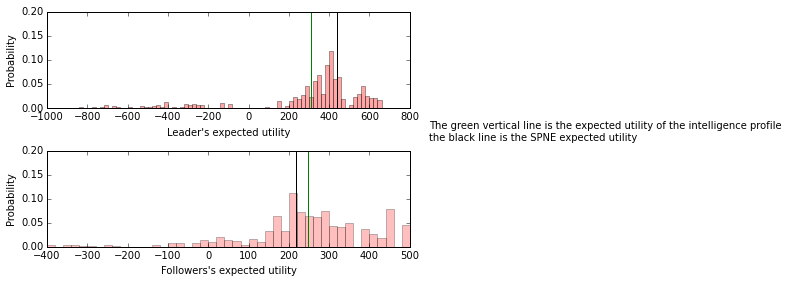

```python
off_path_res1.eu_hist(binwidth=20, power=1);
```

Let's see when the off path intel weight increases to .25

```python
combined_intels = []
off_path_weight=.25
for ix, s in enumerate(perfect_stratprofiles):
      combined_intels.append( (1 - off_path_weight) * on_path_intel[ix] + off_path_weight * get_off_path_intel_perfect_info(s))
```

```python
off_path_res = TremblingIntelResults(combined_intels) # Class name is a misnomer.  Can be used for any results class
```

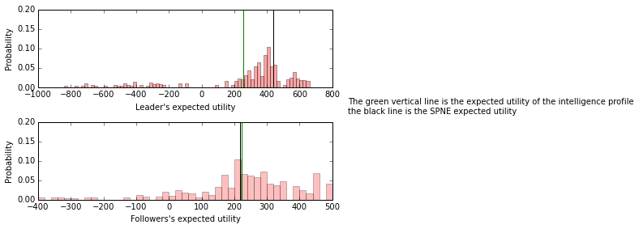

```python
off_path_res.eu_hist(binwidth=20, power=1);
```

And now to .5

```python
combined_intels5 = []
off_path_weight=.5
for ix, s in enumerate(perfect_stratprofiles):
      combined_intels5.append( (1 - off_path_weight) * on_path_intel[ix] + off_path_weight * get_off_path_intel_perfect_info(s))
```

```python
off_path_res5 = TremblingIntelResults(combined_intels5) # Class name is a misnomer.  Can be used for any results class
```

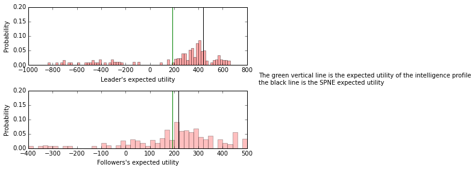

```python
off_path_res5.eu_hist(binwidth=20, power=1);
```

Let's look at the distribution of the differences in intelligences between the one with .1 weight on off path and .5 weight on off path.

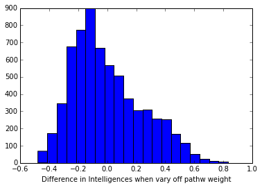

```python
fig, ax = plt.subplots(1)
ax.hist((off_path_res1.res/np.sum(off_path_res1.res) - off_path_res5.res/np.sum(off_path_res5.res)) *
            (np.sum(off_path_res1.res) + np.sum(off_path_res5.res)/2), bins=20)
ax.set_xlabel("Difference in Intelligences when vary off pathw weight");
```

And just for the heck of it, let's take a look at the difference in the 10% trembling intelligences vs the off-path intelligence. This is with a power of 1.

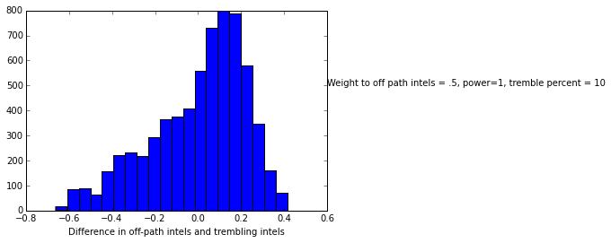

```python
fig, ax = plt.subplots()
ax.hist( (off_path_res5.res/np.sum(off_path_res5.res) - res_tremble10.res/np.sum(res_tremble10.res)) *
           (np.sum(off_path_res5.res) + np.sum(res_tremble10.res))/2., bins=20)
ax.set_xlabel("Difference in off-path intels and trembling intels")
ax.text(.6, 500, "Weight to off path intels = .5, power=1, tremble percent = 10")
```

# Brief summary of both intelligence measures in games of perfect information

### For "off-path" intelligence

- The parameters we control here are again the power parameter but also the weight we give to off path intelligences
- Varying the weight on off path intelligence can have rather significant effects on expected values.

### Comparing and both

- In both models, changing the parameters also changes the order of profiles when ranked in order of intelligence
- The off-path intelligence and the trembling intelligence do not necessarily agree, and can produce different results. However, I think that in general, there will exist parameters for both that yield the same PGT distribution.
- One thing we want to keep in mind is that we want to assign lower probabilities to profiles with larger threats. Since intelligence is ordinal in both the trembling and the off-path intelligence calculations, changes in payoffs might not necessarily lead to changes in intelligences (more on this to come).

# Games of Imperfect Information

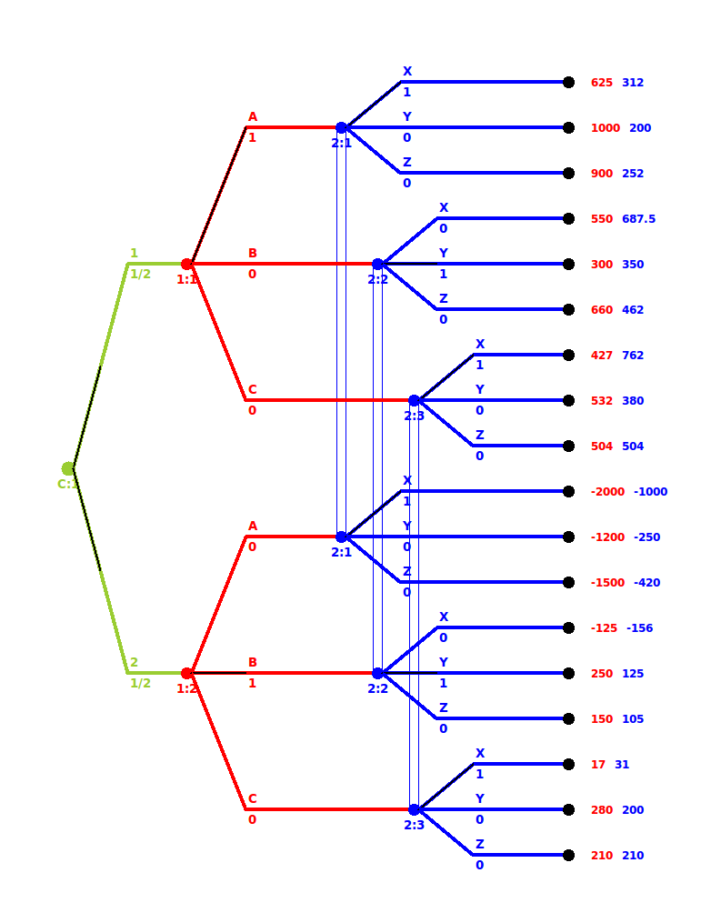

```python
Image('/home/justin/gmetree.png')
```

First, let's look at the "information set" intelligence,

### Some More Code

```python
import itertools
from adsy.display import extended_styles
strat_1 = list(itertools.product(["A", "B", "C"], ["A", "B", "C"]))
strat_2 = list(itertools.product(["X", "Y", "Z"], ["X", "Y", "Z"], ["X", "Y", "Z"]))
```

```python
def EU_imperfect(p1strat, p2strat, utils=utils, p1top2map=mapdict):
    highukey = "H"+p1strat[0]+p2strat[mapdict[p1strat[0]]]
    lowukey =  "L"+p1strat[1]+p2strat[mapdict[p1strat[1]]]
    p1eu = .5 * utils[highukey][0] + .5 * utils[lowukey][0]
    p2eu = .5 * utils[highukey][1] + .5 * utils[lowukey][1]
    return p1eu, p2eu
```

```python
imperfect_stratprofiles = list(itertools.product(strat_1, strat_2))
```

```python
def get_intelligence_imperfect(profile):
    p1strat = profile[0]
    p2strat = profile[1]
    util = EU_imperfect(p1strat, p2strat)
    #print util
    p1_numalt = float(len(strat_1))
    p2_numalt = float(len(strat_2))
    num_no_betterp1 = 0
    num_no_betterp2 = 0
    for s in strat_1:
        if EU_imperfect(s, p2strat)[0] <= util[0]:
            num_no_betterp1 +=1
    for s in strat_2:
        if EU_imperfect(p1strat, s)[1] <= util[1]:
            num_no_betterp2 +=1
    return (num_no_betterp1-1)/(p1_numalt - 1) * (num_no_betterp2 - 1)/(p2_numalt -1)
```

```python
# This is the full game intels
imperfect_infoset_intels = []
for p in imperfect_stratprofiles:
    imperfect_infoset_intels.append(get_intelligence_imperfect(p))
```

```python
# Now start calculating off path intels
```

```python
def get_off_path_info_sets_imperfect(profile):
    unvisited = set(["A", "B", "C"]) - set(list(profile[0]))
    return unvisited
```

```python
def get_off_path_intel_imperfect(profile, p=.5):
    unvisited = list(get_off_path_info_sets_imperfect(profile))
    unvisited_intels = []
    for u in unvisited:
        num_no_better_high = 0.
        num_no_better_low = 0.
        p2s_action = profile[1][mapdict[u]]
        utility_high = utils["H" + u + p2s_action][1]
        utility_low = utils["L" + u + p2s_action][1]
        p2s_other_actions = list(set(["X", "Y", "Z"]) - set(p2s_action))
        for other in p2s_other_actions:
            utility_high_other = utils["H" + u + other][1]
            utility_low_other = utils["L" + u + other][1]
            if utility_high_other <= utility_high:
                num_no_better_high +=1
            if utility_low_other <= utility_low:
                num_no_better_low +=1
        unvisited_intels.append(p * num_no_better_high/2. + (1-p)* num_no_better_low/2.)


    return sum(unvisited_intels)/float(len(unvisited_intels))
```

```python
off_path_intels = [get_off_path_intel_imperfect(s) for s in imperfect_stratprofiles]
```

```python
full_game_intels = np.asarray(off_path_intels) * np.asarray(imperfect_infoset_intels)
```

```python
class ImperfectResults(object):
    def __init__(self, res, stratprofiles = imperfect_stratprofiles, imperfect_strat_1 = strat_1,
                 imperfect_strat_2=strat_2):
        self.res = np.asarray(res)
        self.stratprofiles = stratprofiles
        self.sorted_ix = np.argsort(self.res)[::-1]
        self.imperfect_strat_1 = imperfect_strat_1
        self.imperfect_strat_2 = imperfect_strat_2

    def make_hist(self):
        plt.hist(self.res)


    def get_perfect_intelligence(self, profile):
        """
        Get's the non-trembling intelligences"""
        p1strat = profile[0]
        p2strat = profile[1]
        util = EU_perfect_info(p1strat, p2strat)
        #print util
        p1_numalt = float(len(self.perfect_strat_1))
        p2_numalt = float(len(self.perfect_strat_2))
        num_no_betterp1 = 0
        num_no_betterp2 = 0
        for s in self.perfect_strat_1:
            if EU_perfect_info(s, p2strat)[0] <= util[0]:
                num_no_betterp1 +=1
        for s in self.perfect_strat_2:
            if EU_perfect_info(p1strat, s)[1] <= util[1]:
                num_no_betterp2 +=1
        return (num_no_betterp1-1)/(p1_numalt - 1) * (num_no_betterp2 - 1)/(p2_numalt -1)


    def EU_imperfect(self, p1strat, p2strat, utils=utils, p1top2map=mapdict):
        highukey = "H"+p1strat[0]+p2strat[mapdict[p1strat[0]]]
        lowukey =  "L"+p1strat[1]+p2strat[mapdict[p1strat[1]]]
        p1eu = .5 * utils[highukey][0] + .5 * utils[lowukey][0]
        p2eu = .5 * utils[highukey][1] + .5 * utils[lowukey][1]
        return p1eu, p2eu

    def eu_dist(self, power = 1, binwidth=10):
        total_prob = np.sum(self.res**power)
        probs = self.res**power/float(total_prob)
        eus = []
        for s in self.stratprofiles:
            eus.append(self.EU_imperfect(s[0], s[1]))
        p1u = defaultdict(int)
        p2u = defaultdict(int)
        for ix, atom in enumerate(eus):
            p1u[int(atom[0]/binwidth) * binwidth ] += probs[ix]
            p2u[int(atom[1]/binwidth) * binwidth ] += probs[ix]
        return p1u, p2u

    def eu_hist(self, power=1, binwidth=10):
        eu_dicts = self.eu_dist(power=power, binwidth=binwidth)
        eu_subgame_perfect = [(625+250)/2. , (312. + 125.)/2.]
        eu_dicts_exact = self.eu_dist(power=power, binwidth=1)
        p1eeu = 0
        p2eeu = 0
        for k, v in eu_dicts_exact[0].iteritems():
            p1eeu += k * v
        for k, v in eu_dicts_exact[1].iteritems():
            p2eeu += k * v
        fig, [ax1, ax2] = plt.subplots(2)
        ax1.bar(eu_dicts[0].keys(), eu_dicts[0].values(), width=binwidth, color='r', alpha=.35)
        ax1.set_xlabel("Leader\'s expected utility")
        ax1.set_ylabel("Probability")
        ax1.vlines(eu_subgame_perfect[0], 0, .2)
        ax1.vlines(p1eeu, 0, .2, color='green')
        ax2.bar(eu_dicts[1].keys(), eu_dicts[1].values(), width=binwidth, color='r', alpha=.25)
        ax2.set_xlabel("Followers\'s expected utility")
        ax2.set_ylabel("Probability")
        ax2.vlines(eu_subgame_perfect[1], 0, .2)
        ax2.vlines(p2eeu, 0, .2, color='green')
        plt.tight_layout()
        fig.text(1, .5, 'The green vertical line is the expected utility of the intelligence profile. \n' + \
                        'The black line is the SPNE expected utility')
        return fig, ax1, ax2

    def eu_cdf(self, power=1):
        p1_dist, p2_dist = self.eu_dist( power = power)
        p1k = p1_dist.keys()
        p1v = p1_dist.values()
        p1_srtd = np.argsort(p1k)
        cumprob_p1 = np.cumsum(np.asarray(p1v)[p1_srtd])
        p2k = p2_dist.keys()
        p2v = p2_dist.values()
        p2_srtd = np.argsort(p2k)
        cumprob_p2 = np.cumsum(np.asarray(p2v)[p2_srtd])
        fig, [ax1, ax2] = plt.subplots(2)
        ax1.plot(np.asarray(p1k)[p1_srtd], cumprob_p1)
        ax1.set_xlabel("CDF of Leader\'s Utility")
        ax2.plot(np.asarray(p2k)[p2_srtd], cumprob_p2)
        ax2.set_xlabel("CDF of Followers\'s Utility")
        plt.tight_layout()
        return fig, ax1, ax2
```

```python
rimp = ImperfectResults(full_game_intels);
```

### Distribution of Expected Utilities with info-set intelligences

Note that this is the average over intels version, not the average over states version

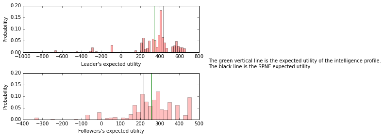

```python
rimp.eu_hist(binwidth=20, power=1);
```

Let's see what happens when we adjust the $p$ parameter

```python
off_path_intels25 = [get_off_path_intel_imperfect(s, p=.2) for s in imperfect_stratprofiles]
```

```python
full_game_intels25 = np.asarray(off_path_intels25) * np.asarray(imperfect_infoset_intels)
```

```python
rimp25 = ImperfectResults(full_game_intels25);
```

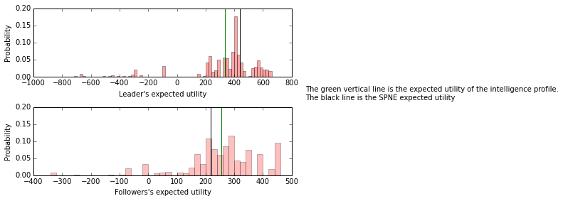

```python
rimp25.eu_hist(binwidth=20, power=1);
```

The distribution of expected utilities is *almost* exactly the same when we vary the $p$ parameter.

### Let's look at the average over states version

```python
def get_off_path_intel_average_over_states(profile, p=.5):
    unvisited = list(get_off_path_info_sets_imperfect(profile))
    unvisited_intels = []
    for u in unvisited:
        num_no_better = 0.
        p2s_action = profile[1][mapdict[u]]
        utility = p * utils["H" + u + p2s_action][1] + (1-p) * utils["L" + u + p2s_action][1]
        p2s_other_actions = list(set(["X", "Y", "Z"]) - set(p2s_action))
        for other in p2s_other_actions:
            utility_other  = p * utils["H" + u + other][1] + (1-p) * utils["L" + u + other][1]
            if utility_other <= utility:
                num_no_better +=1
        unvisited_intels.append(num_no_better/2.)
    return sum(unvisited_intels)/float(len(unvisited_intels))
```

```python
imperfect_infoset_over_states = [get_off_path_intel_average_over_states(s, .5) for s in imperfect_stratprofiles]
```

```python
aosres=ImperfectResults(np.asarray(imperfect_infoset_over_states) * np.asarray(imperfect_infoset_intels))
```

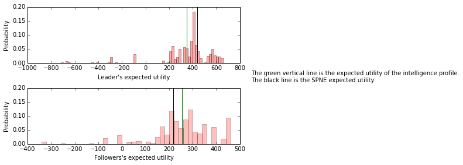

```python
aosres.eu_hist(binwidth=20)
```

```python
imperfect_infoset_over_states5 = [get_off_path_intel_average_over_states(s, .05) for s in imperfect_stratprofiles]
```

```python
aosres5=ImperfectResults(np.asarray(imperfect_infoset_over_states5) * np.asarray(imperfect_infoset_intels))
```

### Varying $p$ parameter

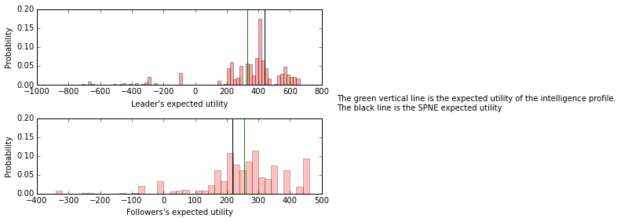

```python
aosres5.eu_hist(binwidth=20)
```

### Summary of imperfect information, information-set intelligences

- The distributions of expected utilities are not sensitive to parameters (except the power parameter)
- The intelligence over states version gives similar results as the "average intelligence" version

### And now the trembling in games of imperfect information

```python
def EU_with_trembles_imperfect(p1strat, p2strat, utils=utils, p1top2map=mapdict, p1trembleprob=.2,
                     p2trembleprob=.2, p1tremblestrats=strat_1, p2tremblestrats=strat_2):
    highukey = "H"+p1strat[0]+p2strat[mapdict[p1strat[0]]]
    lowukey =  "L"+p1strat[1]+p2strat[mapdict[p1strat[1]]]
    p1eunotremb = (1-p2trembleprob) * (.5 * utils[highukey][0] + .5 * utils[lowukey][0])
    p2eunotremb = (1-p1trembleprob) * (.5 * utils[highukey][1] + .5 * utils[lowukey][1])
    ### Get the utility that is associated with p2 trembling
    p1epovern = p1trembleprob/float(len(p1tremblestrats) - 1)
    p2epovern = p2trembleprob/float(len(p2tremblestrats) - 1)
    p1tremblingeu = 0 # Utility of p1 when p2 trembles
    p2tremblingeu = 0 # Utility of p2 when p1 trembles
    for s in p2tremblestrats:
        if s != p2strat:
            highukey = "H"+p1strat[0]+s[mapdict[p1strat[0]]]
            lowukey =  "L"+p1strat[1]+s[mapdict[p1strat[1]]]
            p1tremblingeu += p2epovern * (.5 * utils[highukey][0] + .5 * utils[lowukey][0])
    for s in p1tremblestrats:
        if s != p1strat:
            highukey = "H"+s[0]+p2strat[mapdict[s[0]]]
            lowukey =  "L"+s[1]+p2strat[mapdict[s[1]]]
            p2tremblingeu += p1epovern * (.5 * utils[highukey][1] + .5 * utils[lowukey][1])


    return p1eunotremb + p1tremblingeu, p2eunotremb + p2tremblingeu

def get_trembling_intelligence_perfect(profile):
    p1strat = profile[0]
    p2strat = profile[1]
    util = EU_with_trembles_imperfect(p1strat, p2strat)
    #print util
    p1_numalt = float(len(strat_1))
    p2_numalt = float(len(strat_2))
    num_no_betterp1 = 0
    num_no_betterp2 = 0
    for s in strat_1:
        if EU_with_trembles_imperfect(s, p2strat)[0] <= util[0]:
            num_no_betterp1 +=1
    for s in strat_2:
        if EU_with_trembles_imperfect(p1strat, s)[1] <= util[1]:
            num_no_betterp2 +=1
    return (num_no_betterp1-1)/(p1_numalt - 1) * (num_no_betterp2 - 1)/(p2_numalt -1)
```

```python
imper_tremb_intels = [get_trembling_intelligence_perfect(p) for p in imperfect_stratprofiles]
```

```python
imper_tremb_res = ImperfectResults(imper_tremb_intels)
```

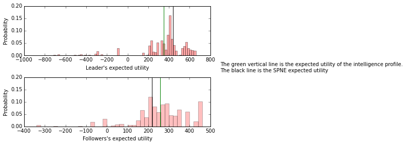

```python
imper_tremb_res.eu_hist(binwidth=20)
```

### Questions that remain

- Why are the results so insensitive to parameter changes?
- What elements of either of these PGT distributions match up with real world behavior (threats and such)?
- Are other quantities of interest as invariant to parameter changes?
- What happens when we change the distribution of the tremble (not just uniform over actions)? Can that affect the results

# Scratch Work and Older Stuff

##### Histogram of Intelligence with 20% tremble

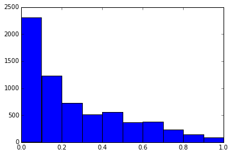

```python
res_tremble20 = TremblingIntelResults(trembling_intels_perfect)
res_tremble20.make_hist()
```

```python
res_tremble10 = TremblingIntelResults(trembling_intels_perfect2)
```

##### Difference in profile intelligences for 1 percent and 20 percent tremble

```python
#plt.hist(res_tremble1.res - res_tremble20.res, bins=20);
```

## #

The expected utilities begin to come together for player 1 but the power has to be very high for the expected utilities to come together for player 2.

#

```python
def print_profile_as_txt(profile):
    p1 = profile[0][0] + " if 1 |" + profile[0][1] + " if 2 "
    p2strat = profile[1]
    p2_1 = p2strat[0] + " if (1, A)| " +  p2strat[1] + " if (1, B)| " + p2strat[2] + " if (1 C)| "
    p2_2 = p2strat[3] + " if (2, A)| " +  p2strat[4] + " if (2, B)| " + p2strat[5] + " if (2 C) "
    return "Player 1: " + p1 + '\n' + "Player 2: " + p2_1 + p2_2 + '\n'
```

```python
for ix in res_tremble10.sorted_ix[:50]:
    strat =  print_profile_as_txt(res_tremble10.stratprofiles[ix])
    if ("C if" in strat) and ("Z if (2, B)" in strat) and ("Z if (2 C)" in strat) :
        print res_tremble10.res[ix], '\n', strat, "There is a noncredible threat in this profile", "\n"
    else:
        print res_tremble10.res[ix], '\n', strat
```

```
1.0
Player 1: A if 1 |B if 2
Player 2: X if (1, A)| X if (1, B)| X if (1 C)| Y if (2, A)| Y if (2, B)| Z if (2 C)

0.998626373626
Player 1: A if 1 |C if 2
Player 2: X if (1, A)| X if (1, B)| X if (1 C)| Y if (2, A)| Z if (2, B)| Z if (2 C)
There is a noncredible threat in this profile

0.997252747253
Player 1: A if 1 |B if 2
Player 2: X if (1, A)| X if (1, B)| X if (1 C)| Z if (2, A)| Y if (2, B)| Z if (2 C)

0.995879120879
Player 1: A if 1 |C if 2
Player 2: X if (1, A)| X if (1, B)| X if (1 C)| Z if (2, A)| Z if (2, B)| Z if (2 C)
There is a noncredible threat in this profile

0.995879120879
Player 1: A if 1 |B if 2
Player 2: X if (1, A)| X if (1, B)| X if (1 C)| Y if (2, A)| Y if (2, B)| X if (2 C)

0.993131868132
Player 1: A if 1 |C if 2
Player 2: X if (1, A)| Z if (1, B)| X if (1 C)| Y if (2, A)| Z if (2, B)| Z if (2 C)
There is a noncredible threat in this profile

0.993131868132
Player 1: A if 1 |B if 2
Player 2: X if (1, A)| Z if (1, B)| X if (1 C)| Y if (2, A)| Y if (2, B)| Z if (2 C)

0.991758241758
Player 1: A if 1 |C if 2
Player 2: X if (1, A)| X if (1, B)| X if (1 C)| Y if (2, A)| Y if (2, B)| Y if (2 C)

0.990384615385
Player 1: A if 1 |B if 2
Player 2: X if (1, A)| X if (1, B)| Z if (1 C)| Y if (2, A)| Y if (2, B)| Z if (2 C)

0.989010989011
```

[output cut: 156 more lines]

```
Player 1: A if 1 |B if 2
Player 2: X if (1, A)| Z if (1, B)| Z if (1 C)| Z if (2, A)| Y if (2, B)| Z if (2 C)

0.949175824176
Player 1: A if 1 |B if 2
Player 2: X if (1, A)| Z if (1, B)| Z if (1 C)| Y if (2, A)| Y if (2, B)| X if (2 C)

0.949175824176
Player 1: A if 1 |C if 2
Player 2: X if (1, A)| Y if (1, B)| X if (1 C)| Y if (2, A)| Z if (2, B)| Y if (2 C)

0.946428571429
Player 1: A if 1 |C if 2
Player 2: X if (1, A)| Y if (1, B)| Z if (1 C)| Y if (2, A)| Z if (2, B)| Z if (2 C)
There is a noncredible threat in this profile
```

### Summary

We are now able to identify the subgame perfect equilibrium from the non equilibrium and non-subgame perfect profiles. However, turning this into a PGT distribution is tricky since many non-subgame perfect profiles have high intelligences.

One way around this is that the literature notes that non-credible threats become credible when the cost of the threat is small but the value of the opponent "swallowing" the threat is large. If we can show that this type of PGT distribution follows such a pattern, I think it will become a viable alternative for games of perfect information.

```python
for ix, val in enumerate(no_trembling_intels):
    if val ==1:
        s=perfect_stratprofiles[ix]
        print EU_with_trembles_perfect_info(s[0], s[1], p1trembleprob=0, p2trembleprob=0)
```